# QUES-H RUSLE - Module Report

## 1 Module brief description

QuES-H (Quantification of Ecosystem Services) is a hydrological assessment module that analyzes hydrological environmental services. The current version features a soil erosion risk module based on the Revised Universal Soil Loss Equation (RUSLE), with plans to expand its capabilities to include additional hydrological analyses in the future.

## 2 Input data

### 2.1 Total Annual Precipitation Map

Represents the total rainfall for each pixel over a year (mm/year)

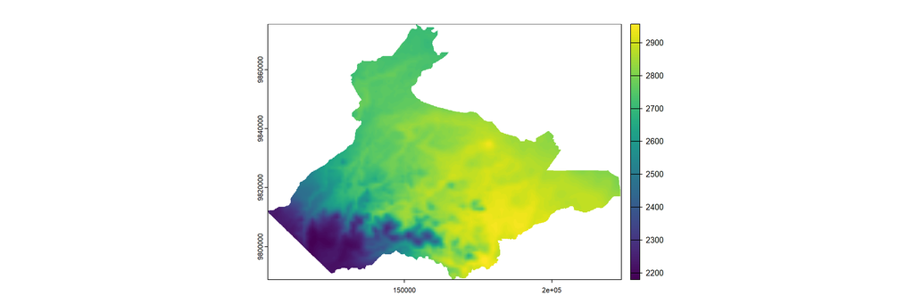

### 2.2 Digital Elevation Model (DEM) Map

Represents the terrain elevation (meters above sea level)

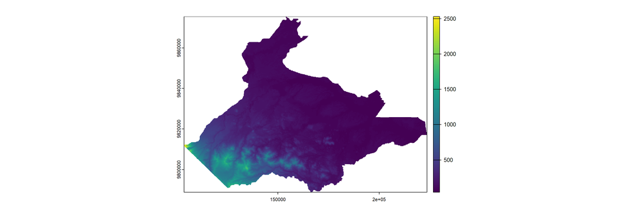

### 2.3 Soil Properties Maps

Represents the soil characteristic, defined by Clay content (%), Silt content (%), Sand content (%), and Soil organic content (g/kg)

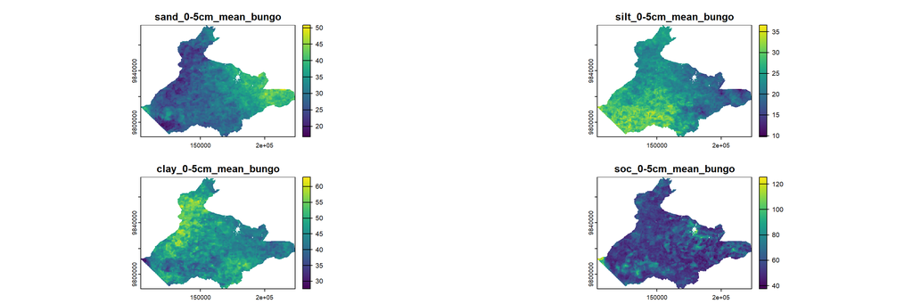

### 2.4 Land Cover Map

Categorical raster with each pixel value corresponds to a land cover class

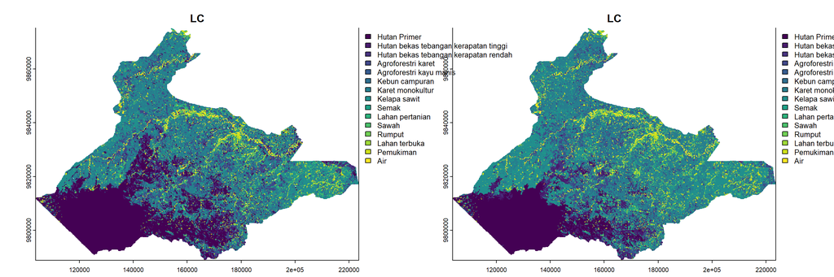

### 2.5 Planning Unit Map

A polygon shapefile of administrative or management zones.

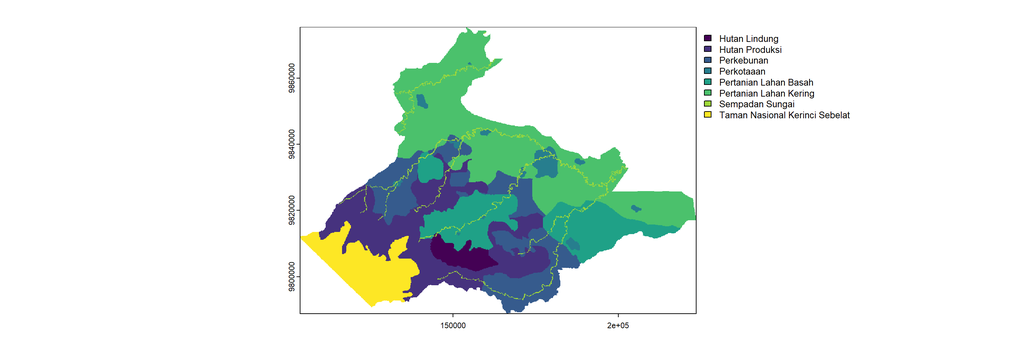

## 3 Results

### 3.1 Factor of RUSLE

#### 3.1.1 R Factor: Rainfall Erosivity

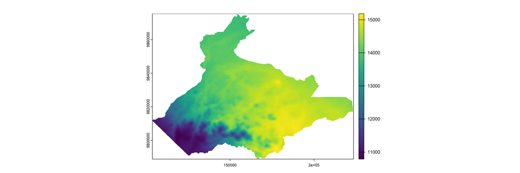

#### 3.1.2 K Factor: Soil Erodibility

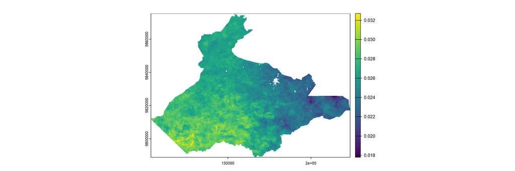

#### 3.1.3 LS Factor: Length and Steepness

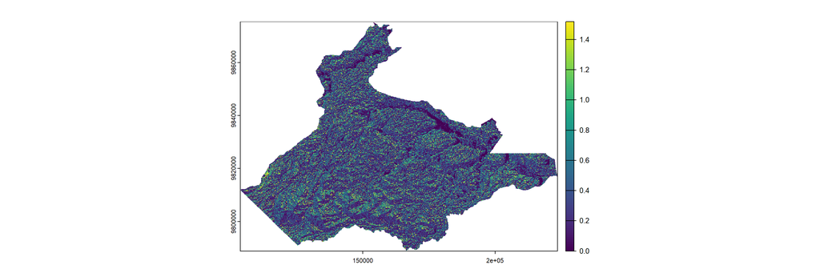

#### 3.1.4 C Factor: Cover Management

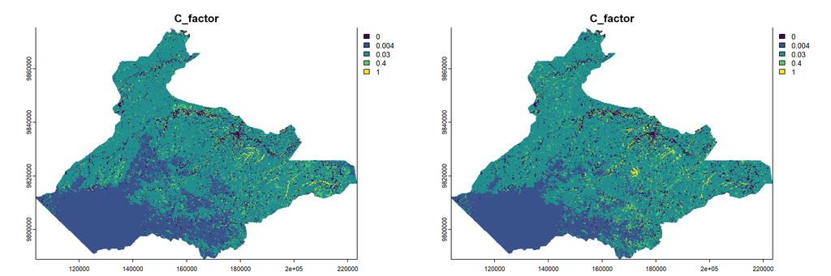

#### 3.1.5 P Factor: Practice Management

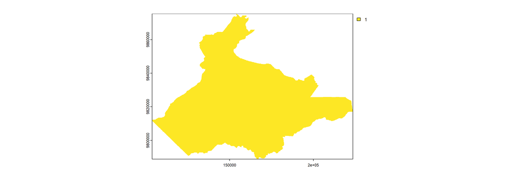

### 3.2 Estimation of Soil Erosion

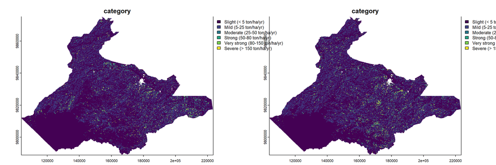

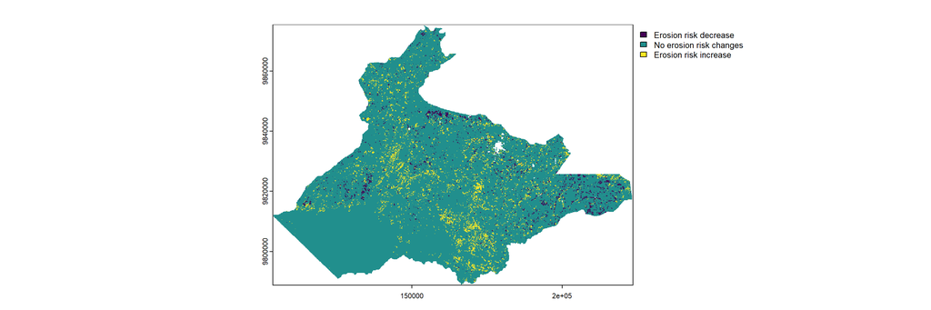